# Audit: RAIS formal employment aggregate

## Q2. Which municipality-years have no RAIS rows?

What is checked: the 808 × 26 grid against the rows present, and the missing municipality-years of the Amazon-biome sample in 2000-2020, which the panel carries as NA employment.

```r
grid <- expand_grid(geocode = unique(rais_raw$geocode), year = 1999:2024)
missing <- grid %>% anti_join(rais, by = c("geocode", "year"))
nrow(missing)
```

```
[1] 140
```

```r
missing %>% count(year) %>% print(n = 30)
```

```
# A tibble: 15 × 2
    year     n
   <int> <int>
 1  1999    41
 2  2000    46
 3  2001    16
 4  2002    13
 5  2003     5
 6  2004     4
 7  2005     3
 8  2006     1
 9  2007     1
10  2008     4
11  2009     2
12  2010     1
13  2011     1
14  2012     1
15  2015     1
```

```r
missing %>% filter(geocode %in% biome_amz$Geocódigo, year %in% 2000:2020) %>%
  count(geocode, name = "years_missing") %>% arrange(desc(years_missing)) %>% print(n = 30)
```

```
# A tibble: 30 × 2
   geocode years_missing
   <chr>           <int>
 1 1504752            13
 2 2100832             5
 3 5104526             5
 4 5104542             5
 5 2102150             4
 6 1400704             3
 7 2105658             3
 8 2108256             2
 9 2109239             2
10 2112274             2
11 1400233             1
12 1507466             1
```

[output cut: 18 more lines]

```r
missing %>% filter(geocode %in% biome_amz$Geocódigo, year %in% 2000:2020) %>% nrow()
```

```
[1] 64
```

**Finding.** The gaps concentrate in the early years and in municipalities installed after 2000 (which have no bonds before installation) and in a few small municipalities with no active bond in a year. Within the Amazon-biome sample and the 2000-2020 window, 64 municipality-years are absent: 13 are Mojuí dos Campos before 2013 (dropped downstream), and the remaining 51 are the rows the recovered panel shows as NA in every `emp_*` column (phase 1 check). The script does not fill them: a missing municipality-year is not a zero. **Decision.** none required; task 1.8 (NA versus zero) documents the rule. **Assertion.** none in script 02 (the grid is completed in script 04).

## Q3. Where do the agricultural wage-group counts and the shares turn NA?

What is checked: the inherited `replace_na()` defect, which filled the all-worker wage-group counts with 0 but left the agricultural ones NA where a municipality-year has no bond at all in that wage group, and the 0 / 0 shares (task 1.8).

```r
rais %>%
  summarise(across(c(workers_low, workers_mid, workers_high), ~ sum(is.na(.x)),
                   .names = "na_{.col}"),
            across(c(workers_agri_low, workers_agri_mid, workers_agri_high), ~ sum(is.na(.x)),
                   .names = "na_{.col}"),
            zero_workers_agric = sum(workers_agric == 0))
```

```
# A tibble: 1 × 7
  na_workers_low na_workers_mid na_workers_high na_workers_agri_low na_workers_agri_mid na_workers_agri_high
           <int>          <int>           <int>               <int>               <int>                <int>
1              0              0               0                   0                   0                    0
# ℹ 1 more variable: zero_workers_agric <int>
```

```r
rais %>%
  summarise(across(starts_with("emp_share_agri_"), ~ sum(is.na(.x)), .names = "na_{.col}"),
            rows = n())
```

```
# A tibble: 1 × 5
  na_emp_share_agri_low_workers na_emp_share_agri_mid_wo…¹ na_emp_share_agri_hi…² na_emp_share_agri_wo…³  rows
                          <int>                      <int>                  <int>                  <int> <int>
1                          2718                       2718                   2718                      0 20868
# ℹ abbreviated names: ¹na_emp_share_agri_mid_workers, ²na_emp_share_agri_high_workers,
#   ³na_emp_share_agri_workers
```

```r
rais %>%
  mutate(agri_zero = workers_agric == 0, high_na = is.na(workers_agri_high)) %>%
  count(agri_zero, high_na)
```

```
# A tibble: 2 × 3
  agri_zero high_na     n
  <lgl>     <lgl>   <int>
1 FALSE     FALSE   18150
2 TRUE      FALSE    2718
```

## Q4. How are the rates and shares distributed?

What is checked: quantiles by year of the PIA rates and the wage shares, and the municipality-years with a rate above one.

```r
rais %>%
  filter(year %in% c(2000, 2005, 2010, 2015, 2020, 2024)) %>%
  group_by(year) %>%
  summarise(across(c(emp_pia_rate_total, emp_share_low_workers, emp_share_agri_workers),
                   list(p10 = ~ quantile(.x, .1, na.rm = TRUE), p50 = ~ median(.x, na.rm = TRUE),
                        p90 = ~ quantile(.x, .9, na.rm = TRUE)))) %>%
  pivot_longer(-year) %>% pivot_wider(names_from = year, values_from = value)
```

```
# A tibble: 9 × 7
  name                        `2000` `2005` `2010`  `2015`  `2020`  `2024`
  <chr>                        <dbl>  <dbl>  <dbl>   <dbl>   <dbl>   <dbl>
1 emp_pia_rate_total_p10     0.00195 0.0167 0.0379 0.0456  0.0457  0.00652
2 emp_pia_rate_total_p50     0.0341  0.0646 0.0924 0.104   0.0940  0.0577
3 emp_pia_rate_total_p90     0.123   0.183  0.228  0.260   0.245   0.236
4 emp_share_low_workers_p10  0.403   0.381  0.206  0.108   0.0750  0.0685
5 emp_share_low_workers_p50  0.746   0.678  0.396  0.231   0.152   0.130
6 emp_share_low_workers_p90  0.945   0.938  0.632  0.426   0.321   0.247
7 emp_share_agri_workers_p10 0       0      0      0.00102 0.00117 0.00482
8 emp_share_agri_workers_p50 0.0320  0.0608 0.0553 0.0589  0.0633  0.154
9 emp_share_agri_workers_p90 0.361   0.308  0.282  0.270   0.294   0.485
```

```r
rais %>% filter(emp_pia_rate_total > 1) %>% select(geocode, year, workers_total, pia)
```

```
# A tibble: 3 × 4
  geocode  year workers_total    pia
  <chr>   <int>         <int>  <dbl>
1 1720259  2007          2355  1982.
2 5107800  2000         11094 10981
3 5107800  2001         13686 11294.
```

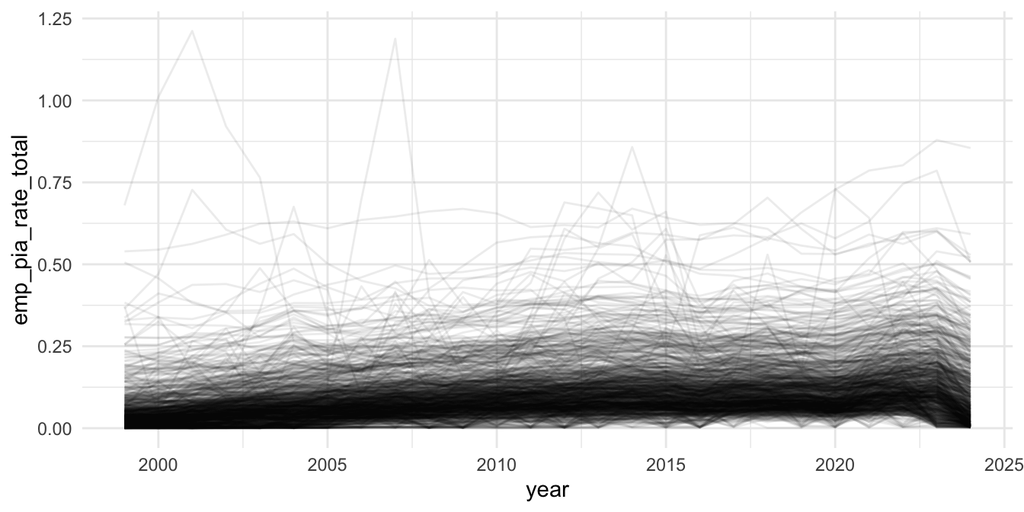

```r
rais %>%
  ggplot(aes(year, emp_pia_rate_total, group = geocode)) +
  geom_line(alpha = 0.08) + theme_minimal()
```

**Finding.** The median municipality has formal employment near 3 percent of its working-age population in 2000 and about 10 percent by the mid-2010s; the median low-wage share of bonds falls from 75 to 13 percent. Three municipality-years exceed a rate of one (5107800 in 2000-2001, 1720259 in 2007), where the bonds counted outnumber the interpolated PIA; kept as inherited. **Decision.** none required. **Assertion.** `02-social-rais.R`, output block (counts add up; shares within 0-1).